# Practicum 1

Nithya Sarabudla

02-11-2024

## 1 / Predicting Diabetes to your notebook

### 1.1 / Analysis of Data Distribution

```r
# Define the target columns to replace 0 values with NA
target_columns <- c("Glucose", "BloodPressure", "SkinThickness", "Insulin", "BMI")
diabetes[target_columns] <- lapply(diabetes[target_columns], function(x) replace(x, x == 0, NA))
```

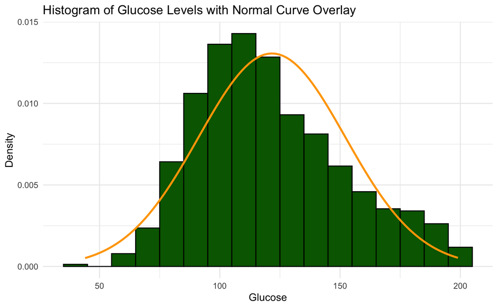

The above plot shows the distribution of glucose levels, with an overlaid normal distribution curve in orange. The histogram’s bars, which indicate density, suggest that the data is somewhat normally distributed, but with a rightward skew as evidenced by the tail extending towards higher glucose values. The presence of this skew might imply that a subset of the population has higher glucose levels, which could be of interest in medical studies or public health policy. The normal curve overlay helps to visualize how closely the actual data follows a normal distribution, which is essential for many statistical analyses that assume normality.

```
    Shapiro-Wilk normality test

data:  diabetes$Glucose
W = 0.96964, p-value = 1.72e-11
```

### 1.2 / Identification of Outliers

```r
# Define the variables
selected_vars <- c("Pregnancies", "Glucose", "BloodPressure", "SkinThickness", "Insulin", "BMI", "DiabetesPedigreeFunction", "Age")
# Apply a function to each variable in the 'diabetes' dataset
outliers <- lapply(diabetes[selected_vars], function(var) {
  # Calculate mean and standard deviation of the variable, ignoring NA values
  var_mean <- mean(var, na.rm=TRUE)
  var_sd <- sd(var, na.rm=TRUE)
  # Calculate z-scores for each observation
  z_scores <- abs((var - var_mean) / var_sd)
  # Identify outliers based on z-score threshold (2.5)
  outliers_index <- which(z_scores > 2.5)
  # Create a data frame with indices and corresponding z-scores for outliers
  return(data.frame(Indices = outliers_index, Z_Scores = z_scores[outliers_index]))
})
```

In dataset, used statistical method called the Z-score to find outliers, which are values that are unusually high or low. The Z-score tells us how far away a value is from the average, measured in standard deviations. We decided that any value more than 2.5 standard deviations away from the mean should be considered an outlier.

For the given dataset, outliers were identified in the columns of ‘Pregnancies’, ‘Glucose’, ‘BloodPressure’, ‘SkinThickness’, ‘Insulin’, ‘BMI’, ‘DiabetesPedigreeFunction’, and ‘Age’. A total of 97 outliers were identified across all columns

Pregnancies: 14 outliers Glucose: 2 outliers BloodPressure: 14 outliers SkinThickness: 4 outliers Insulin: 17 outliers BMI: 9 outliers DiabetesPedigreeFunction: 20 outliers Age: 17 outliers

The identification of these outliers is crucial since they can significantly affect the mean and standard deviation of the data, leading to biased results in statistical analyses. Depending on the context, outliers can be removed, capped, or investigated further to understand their cause. For instance, in medical datasets like this, extreme values could indicate measurement errors, data entry errors, or genuine but rare medical conditions.

### 1.3 / Data Preparation

```r
# Define the function for z-score standardization
standardize <- function(column) {
  # Subtract the mean and divide by the standard deviation
  (column - mean(column, na.rm = TRUE)) / sd(column, na.rm = TRUE)
}

# Create a copy of the original dataset
standardized_data <- diabetes
# Apply z-score standardization to all numeric columns using the defined function
standardized_data[selected_vars] <- lapply(diabetes[selected_vars], standardize)


# Extract indices of all outliers across all variables
all_outlier_indices <- unique(unlist(lapply(outliers, function(df) df$Indices)))

# Remove rows containing outliers
cleaned_data <- diabetes[-all_outlier_indices, ]

# Apply z-score standardization again to cleaned dataset
cleaned_data[selected_vars] <- lapply(cleaned_data[selected_vars], standardize)

# Print summary statistics of the original dataset
summary(diabetes)
```

```
  Pregnancies        Glucose      BloodPressure    SkinThickness      Insulin           BMI
 Min.   : 0.000   Min.   : 44.0   Min.   : 24.00   Min.   : 7.00   Min.   : 14.0   Min.   :18.20
 1st Qu.: 1.000   1st Qu.: 99.0   1st Qu.: 64.00   1st Qu.:22.00   1st Qu.: 77.0   1st Qu.:27.50
 Median : 3.000   Median :117.0   Median : 72.00   Median :29.00   Median :125.0   Median :32.30
 Mean   : 3.852   Mean   :121.7   Mean   : 72.44   Mean   :29.15   Mean   :155.9   Mean   :32.45
 3rd Qu.: 6.000   3rd Qu.:141.0   3rd Qu.: 80.00   3rd Qu.:36.00   3rd Qu.:190.0   3rd Qu.:36.60
 Max.   :17.000   Max.   :199.0   Max.   :122.00   Max.   :99.00   Max.   :846.0   Max.   :67.10
                                  NA's   :35       NA's   :227     NA's   :370     NA's   :11
 DiabetesPedigreeFunction      Age           Outcome
 Min.   :0.0780           Min.   :21.00   Min.   :0.0000
 1st Qu.:0.2435           1st Qu.:24.00   1st Qu.:0.0000
 Median :0.3740           Median :29.00   Median :0.0000
 Mean   :0.4725           Mean   :33.27   Mean   :0.3486
 3rd Qu.:0.6265           3rd Qu.:41.00   3rd Qu.:1.0000
 Max.   :2.4200           Max.   :81.00   Max.   :1.0000
```

The ‘standardize()’ function calculates z-scores for each column, which is a common method for normalizing data. Z-score standardization transforms the data so that it has a mean of 0 and a standard deviation of 1. This is done to ensure that all features contribute equally to the analysis, especially in models that are sensitive to the scale of variables, such as regression models.

A copy of the original dataset (‘standardized_data’) is created to keep the original intact.

The ‘standardize()’ function is applied to all numeric columns in the ‘selected_vars’ list using ‘lapply()’.

The indices of all outliers across all variables are extracted using the ‘outliers’ list.

Rows containing outliers are removed from the original dataset, and the cleaned dataset is stored in ‘cleaned_data’.

Z-score standardization is applied again to the cleaned dataset to ensure consistency.

Summary statistics of the original dataset are printed to examine its distribution before preprocessing.

### 1.4 / Sampling Training and Validation Data

```r
# Set seed for reproducibility
set.seed(123)

# Create stratified sampling indices
split <- createDataPartition(cleaned_data$Outcome, p = 0.8, list = FALSE)

# Split data into training and validation sets based on the sampling indices
training_data <- cleaned_data[split, ]
validation_data <- cleaned_data[-split, ]

# Define numeric columns for imputation
numeric_columns <- c("Pregnancies", "Glucose", "BloodPressure", "SkinThickness", "Insulin", "BMI", "DiabetesPedigreeFunction", "Age")

# Impute missing values in training data using median of respective column
training_data[, numeric_columns] <- lapply(training_data[, numeric_columns], function(x) {
  if(any(is.na(x))) x[is.na(x)] <- median(x, na.rm = TRUE)
  x
})

# Impute missing values in validation data using median of corresponding column in training data
validation_data[, numeric_columns] <- lapply(names(validation_data[, numeric_columns]), function(column_name) {
  columns <- validation_data[[column_name]]
  if(any(is.na(columns))) {
    columns[is.na(columns)] <- median(training_data[[column_name]], na.rm = TRUE)
  }
  return(columns)
})
```

Initially, the data is split into training and validation sets using stratified sampling to ensure that both sets maintain the proportion of outcome classes. Numeric columns with missing values are identified, and imputation is performed using the median value of each respective column. This ensures that the imputed values are representative of the dataset and helps maintain the integrity of the data. Specifically, missing values in the training set are replaced with the median value of the corresponding column, while missing values in the validation set are imputed using the median values from the training set. These steps ensure that both training and validation datasets are processed consistently, minimizing biases and ensuring reliable model performance evaluation. Additionally, setting a seed for random number generation ensures reproducibility of results across different runs of the code.

### 1.5 / Predictive Modeling

```r
# Define the new data point
new_data_point <- data.frame(Pregnancies = 4, Glucose = 178, BloodPressure = 82, SkinThickness = 32, Insulin = NA, BMI = 37, DiabetesPedigreeFunction = 0.602, Age = 54)

# Impute missing Insulin value with median from the training data
new_data_point$Insulin <- median(training_data$Insulin, na.rm = TRUE)

# Define a function to standardize columns based on mean and standard deviation
standardize <- function(column, mean_value, sd_value) {
  (column - mean_value) / sd_value
}

# Calculate mean and standard deviation for each column in the training data
training_means <- sapply(training_data[selected_vars], mean, na.rm = TRUE)
training_sds <- sapply(training_data[selected_vars], sd, na.rm = TRUE)

# Standardize the new data point using means and standard deviations from training data
new_data_point[selected_vars] <- lapply(selected_vars, function(var_name) {
  standardize(new_data_point[[var_name]], training_means[var_name], training_sds[var_name])
})

# Use kNN algorithm to predict the outcome for the new data point
predicted_outcome <- knn(train = training_data[, -ncol(training_data), drop = FALSE],
                          test = new_data_point,
                          cl = training_data$Outcome,
                          k = 5)

# Add the predicted outcome to the new data point
new_data_point$Outcome <- predicted_outcome

# Print the predicted outcome
print(predicted_outcome)
```

```
[1] 1
Levels: 0 1
```

Defined a new data point with missing Insulin value. Imputed the missing Insulin value using the median from the training data to maintain consistency. Defind a function standardize to standardize columns based on mean and standard deviation. Calculated the mean and standard deviation for each column in the training data. standardized the new data point using means and standard deviations from the training data to ensure comparability. Used the kNN algorithm from the class package to predict the outcome for the new data point based on the training data. Finally, printed the predicted outcome. In this case, the predicted outcome is 1, indicating a positive diabetes diagnosis.

## 2 / Predicting Age of Abalones using Regression kNN

### 2.1 / loading and preparing the data

We start by loading the dataset containing abalone information using ‘read.csv()’, storing it in ‘abalone_data’. Then, we extract the target variable “NumRings”, representing abalone age, and store it in ‘target_data’. We create ‘train_data’, a dataset containing all features except “NumRings”, for training our model. This dataset includes attributes like Length, Diameter, Height, ShuckedWeight, VisceraWeight, ShellWeight, WholeWeight, and Sex. Displaying the first few rows of ‘train_data’ allows us to verify that the data is loaded and prepared correctly for further analysis and modeling.

```r
# Loading the dataset
abalone_data <- read.csv("/Users/nithyasarabudla/Downloads/abalone.csv")

# Extracting the target variable "Rings" and storing it in a separate vector called target_data
target_data <- abalone_data$NumRings

# Creating a new dataset train_data containing all features except "Rings"
train_data <- abalone_data[, -which(names(abalone_data) == "NumRings")]
```

### 2.2 / Encoding Categorical Variables

```r
# Encoding categorical variables
encode_data <- model.matrix(~ Sex - 1, data = train_data)
# Adding the encoded columns to the training dataset
train_data <- cbind(train_data, encode_data)

# Removing the original "Sex" column from the dataset
train_data <- train_data[, -which(names(train_data) == "Sex")]
# Removing the redundant column created by encoding (SexI)
train_data <- train_data[, -which(names(train_data) == "SexI")]
# Displaying the first few rows of the modified training dataset
head(train_data)
```

|  | Length | Diameter | Height | ShuckedWeight | VisceraWeight | ShellWeight | WholeWeight | SexF | SexM |
| --- | --- | --- | --- | --- | --- | --- | --- | --- | --- |
| 1 | 0.455 | 0.365 | 0.095 | 0.2245 | 0.1010 | 0.150 | 0.5140 | 0 | 1 |
| 2 | 0.350 | 0.265 | 0.090 | 0.0995 | 0.0485 | 0.070 | 0.2255 | 0 | 1 |
| 3 | 0.530 | 0.420 | 0.135 | 0.2565 | 0.1415 | 0.210 | 0.6770 | 1 | 0 |
| 4 | 0.440 | 0.365 | 0.125 | 0.2155 | 0.1140 | 0.155 | 0.5160 | 1 | 0 |
| 5 | 0.330 | 0.255 | 0.080 | 0.0895 | 0.0395 | 0.055 | 0.2050 | 0 | 0 |
| 6 | 0.425 | 0.300 | 0.095 | 0.1410 | 0.0775 | 0.120 | 0.3515 | 0 | 0 |

I choose the “Sex” column as an example for encoding because it represents a common scenario in datasets where certain attributes are categorical rather than numerical. In the dataset of abalones, “Sex” denotes the gender of the abalone, with three categories: “F” for Female, “M” for Male, and “I” for Infant. Encoding categorical variables like “Sex” is crucial for machine learning tasks as many algorithms require numerical inputs. One-hot encoding, a widely used technique, converts categorical variables into binary columns, representing each category as a set of binary features. This approach ensures that the algorithm treats each category independently, avoiding any assumptions of ordinality among the categories.

### 2.3 / Normalize all the columns in train_data using min-max normalization

```r
# Defining a function for min-max normalization
normalize <- function(x){
  ((x - min(x)) / (max(x) - min(x)) )
}
# Identifying numerical columns in the dataset
numerical_columns <- sapply(train_data, is.numeric)
# Applying min-max normalization to numerical columns
train_data[, numerical_columns] <- lapply(train_data[, numerical_columns], normalize)
# Displaying summary statistics of the normalized dataset
summary(train_data)
```

```
     Length          Diameter          Height       ShuckedWeight    VisceraWeight     ShellWeight
 Min.   :0.0000   Min.   :0.0000   Min.   :0.0000   Min.   :0.0000   Min.   :0.0000   Min.   :0.0000
 1st Qu.:0.5068   1st Qu.:0.4958   1st Qu.:0.1018   1st Qu.:0.1245   1st Qu.:0.1224   1st Qu.:0.1281
 Median :0.6351   Median :0.6218   Median :0.1239   Median :0.2253   Median :0.2245   Median :0.2317
 Mean   :0.6068   Mean   :0.5931   Mean   :0.1235   Mean   :0.2411   Mean   :0.2372   Mean   :0.2366
 3rd Qu.:0.7297   3rd Qu.:0.7143   3rd Qu.:0.1460   3rd Qu.:0.3369   3rd Qu.:0.3325   3rd Qu.:0.3264
 Max.   :1.0000   Max.   :1.0000   Max.   :1.0000   Max.   :1.0000   Max.   :1.0000   Max.   :1.0000
  WholeWeight          SexF             SexM
 Min.   :0.0000   Min.   :0.0000   Min.   :0.0000
 1st Qu.:0.1557   1st Qu.:0.0000   1st Qu.:0.0000
 Median :0.2825   Median :0.0000   Median :0.0000
 Mean   :0.2929   Mean   :0.3131   Mean   :0.3657
 3rd Qu.:0.4079   3rd Qu.:1.0000   3rd Qu.:1.0000
 Max.   :1.0000   Max.   :1.0000   Max.   :1.0000
```

### 2.4 / Implementing kNN Regression

```r
knn_regression <- function(new_data, target_data, train_data, k) {
  # Calculate distances between new_data and train_data
  distances <- as.matrix(dist(rbind(new_data, train_data), method = "euclidean"))[1, ]

  # Find indices of k nearest neighbors
  k_nearest_indices <- order(distances)[1:k]
  # Extract Rings values of k nearest neighbors
  k_nearest_rings <- target_data[k_nearest_indices]
  # Define weights for weighted average
  weights <- c(3, rep(2, k - 2), rep(1, length(k_nearest_indices) - k + 1))
  # Calculate predicted Rings value using weighted average
  predicted_value <- sum(k_nearest_rings * weights) / sum(weights)
  # Return the predicted Rings value
  return(predicted_value)
}

# Generating new_data as a data frame structured similarly to train_data
# replacing 1 in place of the "Female" column (since "Male" and "Infant" were removed during one-hot encoding)
new_data <- c(0.465,    0.356,  0.093,  0.234,  0.103,  0.14,   0.524, 0, 1)

# Predicting the Rings value for the new_data using knn_regression function with k = 3
predicted_rings <- knn_regression(new_data, target_data, train_data, k = 3)

print(predicted_rings)
```

```
[1] 11.16667
```

Implemented a kNN regression function named ‘knn_regression’. The function takes four arguments: ‘new_data’ (a data frame with new cases), ‘target_data’ (a data frame with a single column of Rings values), ‘train_data’ (a data frame with normalized and encoded features corresponding to Rings values), and ‘k’ (the number of nearest neighbors to consider).

Using these weights, computed the predicted Rings value as the weighted average of the Rings values of the nearest neighbors. Finally, Return the predicted Rings value.

An example usage of the function is demonstrated using sample new_data, and the predicted Rings value is printed.

### 2.5 / Forecasting Rings for a New Abalone

```r
# Define new_data with attributes for the new abalone
new_data <- c(0.44, 0.391, 0.254, 0.5853, 0.2132, 0.0878, 0.21, 0, 1)
# Predict the Rings value for the new abalone using knn_regression function with k = 3
predicted_rings <- knn_regression(new_data, target_data, train_data, k = 3)
# Print the predicted Rings value
print(predicted_rings)
```

```
[1] 11.33333
```

In this code chunk, the number of Rings for a new abalone is forecasted using a regression kNN algorithm with k=3. First, the attributes of the new abalone, including its physical characteristics such as Length, Diameter, Height, Whole weight, Shucked weight, Viscera weight, and Shell weight, are defined and stored in the new_data vector. Then, the knn_regression function is utilized to predict the Rings value for the new abalone based on its attributes. This function takes the new abalone data (new_data), the target variable (target_data), and the training dataset (train_data) as inputs, along with the specified value of k=3. Finally, the predicted Rings value for the new abalone is printed.

### 2.6 / Calculating Root Mean Squared Error (RMSE) for kNN Model Evaluation

```r
# Start timing
start_time <- Sys.time()

# Specify the proportion of data to be used for testing
test_split <- 0.20

# Create a random split of the data into training and testing sets
train_index <- createDataPartition(target_data, p = 1 - test_split, list = FALSE)
train_data_split <- train_data[train_index, ]
test_data_split <- train_data[-train_index, ]
target_data_split <- target_data[train_index]

# Normalize numerical columns in the test dataset
test_data_split[, numerical_columns] <- lapply(test_data_split[, numerical_columns], normalize)

# Train the kNN regression model using the training data
knn_model <- knn_regression(test_data_split, target_data_split, train_data_split, k = 3)

# Calculate Mean Squared Error (MSE) to evaluate the model
mse <- mean((knn_model - target_data_split)^2)

# Calculate Root Mean Squared Error (RMSE)
rmse <- sqrt(mse)

# Print the RMSE value as a measure of the model's accuracy
print(paste("Root Mean Squared Error (RMSE):", rmse))
```

```
[1] "Root Mean Squared Error (RMSE): 4.81580581480742"
```

```r
# End timing
end_time <- Sys.time()

# Calculate the elapsed time
elapsed_time <- end_time - start_time
print(paste("Elapsed Time:", elapsed_time))
```

```
[1] "Elapsed Time: 0.478376865386963"
```

In this section, Calculate the Root Mean Squared Error (RMSE) for evaluating the kNN regression model. Firstly, split the dataset into training and testing sets, with 20% of the data designated for testing. Then, normalized the numerical columns in the test dataset to ensure consistency with the training data. Trained the kNN regression model using the training data and predict the Rings values for the test dataset. Next,computed the Mean Squared Error (MSE) to evaluate the model’s performance. Finally, calculated the RMSE from the MSE and print the RMSE value as a measure of the model’s accuracy.

Measured the time taken to execute the code block between start_time and end_time and print out the elapsed time. This helps in identifying any bottlenecks in your code and optimizing it for efficiency.

## 3 / Forecasting Future Sales Price

[figure not shown]

We obtained a data set containing 29580 sales transactions for the years 2007 to 2019. The mean sales price for the entire time frame was 609736.3 (sd = 281707.9).

Broken down by year, we have the following average sales prices per year:

| year | average_price |
| --- | --- |
| 2007 | 522377.2 |
| 2008 | 493814.2 |
| 2009 | 496092.0 |
| 2010 | 559564.8 |
| 2011 | 566715.1 |
| 2012 | 552501.4 |
| 2013 | 553416.3 |
| 2014 | 592653.8 |
| 2015 | 626101.3 |
| 2016 | 635185.3 |
| 2017 | 671880.6 |
| 2018 | 660701.0 |
| 2019 | 634184.2 |

Using a weighted moving average forecasting model that averages the prior 3 years (with weights of 4, 3, 1), we predict next year’s average sales price to be around $662976.2.

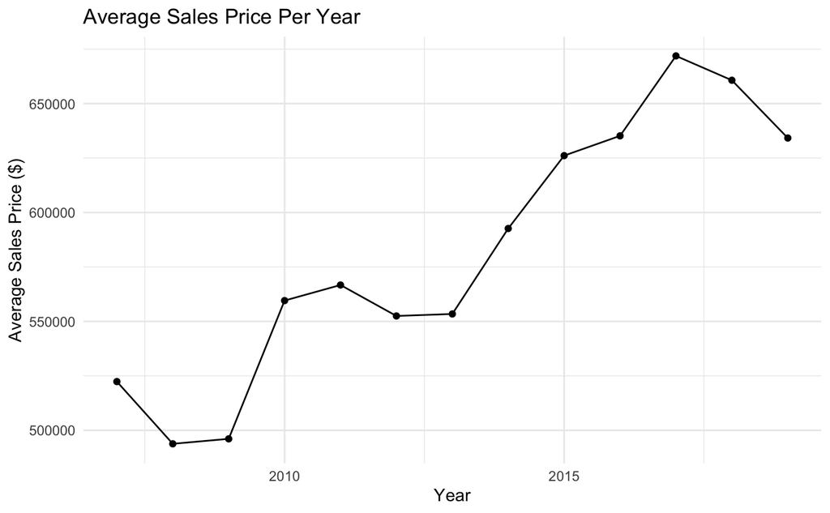